# 08-02. ARIMA 모델 (ARIMA 모델링, 예측, 계절성 ARIMA, ARIMA vs ETS)

## 08.07. R에서 ARIMA 모델링

### `auto.arima()`은 어떻게 작동하는가?

R에서 `auto.arima()` 함수는 힌드만-칸다카르(Hyndman-Khandakar) 알고리즘 (Hyndman & Khandakar, 2008)의 변형된 형태를 사용합니다. `auto.arima()` 함수는 ARIMA 모델을 얻기 위해, 단위 근 검정, AICc 최소화, MLE를 결합하여 사용합니다. 여기에서 설명하는 내용은 기본값으로 설정된 작동 방식입니다.

**자동화된 ARIMA 모델링을 위한 힌드만-칸다카르(Hyndman-Khandakar) 알고리즘**

1. KPSS 검정을 반복하여 차분 횟수$0 \le d\le 2$를 결정합니다.
2. 데이터를 $d$ 번 차분(differencing)한 후에 AICc를 최소화하여 $p$와 $q$를 고릅니다. 이 알고리즘에서는 $p$ 와 $q$의 모든 가능한 조합을 살펴보는 것이 아니라, 모델 공간을 탐색하기 위해 단계적(stepwise) 탐색을 사용합니다.
1. 4개의 초기 모델을 맞춥니다:
   - ARIMA$(0,d,0)$,
   - ARIMA$(2,d,2)$,
   - ARIMA$(1,d,0)$,
   - ARIMA$(0,d,1)$.

   $d=2$가 아니면, 상수를 포함합니다. $d \le 1$이면, 덧셈 모델도 맞춥니다:
   - 상수가 없는 ARIMA$(0,d,0)$.
2. 1. 단계에서 맞춘 (AICc 값이 가장 작은) 가장 좋은 모델을 “현재 모델”로 둡니다.
3. 현재 모형의 변형을 고려합니다:
   - 현재 모델에서 $p$ 와/또는 $q$를 $\pm1$로 바꿉니다;
   - $c$를 현재 모델에 포함시킵니다/제외합니다.

지금까지 고려한 (현재 모델이나 이러한 변형 중에 하나) 가장 좋은 모델이 새로운 현재 모델이 됩니다.

4. 더 작은 AICc가 나오지 않을 때까지 2(c) 단계를 반복합니다

기본적인 과정은 찾는 속도를 높이기 위해 몇 가지 근사 과정을 사용합니다. 입력값 `approximation=FALSE`으로 이러한 근사를 생략할 수 있습니다. 이러한 근사나 단계별 탐색 과정 때문에 최소 AICc를 갖는 모델을 찾지 못할 수도 있습니다. 입력값 stepwise=FALSE을 사용하면, 훨씬 더 큰 모델의 모음을 검색합니다. 입력값 전체를 설명하는 내용은 도움말 파일을 참조하시길 바랍니다.

### 모델을 고르기

여러분만의 모델을 고르고 싶다면, R에서 `Arima()` 함수를 사용하시길 바랍니다. R에서 ARIMA 모델을 맞추는 `arima()`라는 또 다른 함수도 있습니다. 하지만, 이 함수는 $ d = 0$ 이 아닐 때 상수$ c$ 를 제외하고, forecast 패키지로 작업할 수 있는 다른 함수에서 필요하는 것을 출력값으로 내지 않습니다.

마지막으로, 이 함수는 새로운 데이터에 적용하기 위한 추정된 모델을 사용할 수 없습니다(이러한 추정된 모델은 예측 정확도를 확인할 때 유용합니다). 결과적으로 대신에 `Arima()` 함수를 사용하길 추천합니다.

### 모델링 과정

ARIMA 모델을 (비-계절성) 시계열 데이터 모음에 맞출 때, 다음과 같은 과정은 유용한 일반적인 접근 방식이 될 수 있습니다.

힌드만-칸다카르(Hyndman-Khandakar) 알고리즘은 3–5 단계만 처리합니다. 그래서 여러분이 이 알고리즘을 사용하더라도, 여전히 여러분 스스로 나머지 단계를 처리해야할 필요가 있습니다.

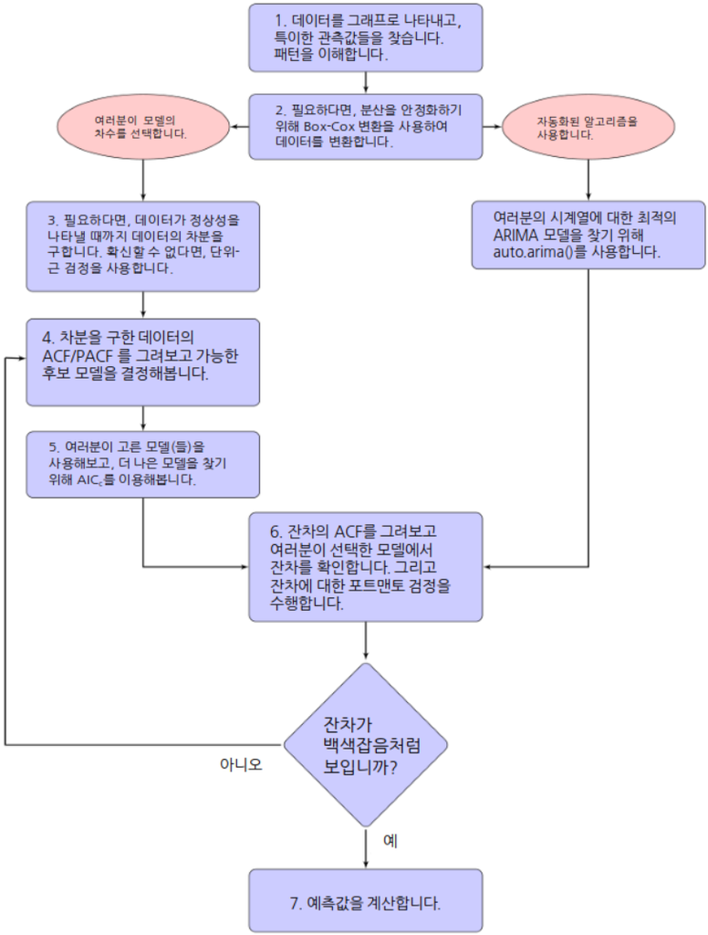

### 예제: 계절성으로 조정된 전자 장비 주문량

- 계절성으로 조정된 전자 장비 주문량 데이터에 적용

```r
library(tidyverse)
library(fpp3)
library(fpp2)
library(fpp)
library(forecast)
```

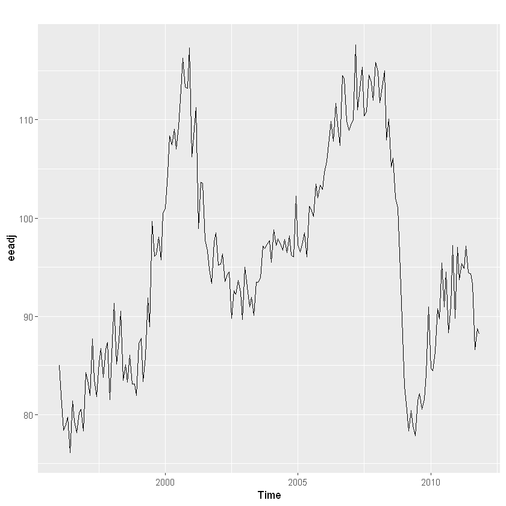

```r
elecequip %>% stl(s.window='periodic') %>% seasadj -> eeadj
autoplot(eeadj)
```

1. 시간 그래프는 몇몇 갑작스런 변화를 나타냅니다. 특별히 2008/2009년에 크게 하락합니다. 이러한 변화는 전세계적인 경제 상황 때문에 일어났습니다. 이외에는 시간 그래프에서 특별한 점이 없고 데이터 조정이 필요한 것 같이 보이진 않습니다.
2. 분산이 변한다는 증거가 없으니, 박스-칵스(Box-Cox) 변환을 하지 않을 것입니다.
3. 장기적으로 볼 때 시계열이 위아래로 출렁이기 때문에 데이터가 정상성을 나타내지 않는다는 것이 분명합니다. 결과적으로, 데이터에서 1차 차분을 구할 것입니다.

차분을 구한 데이터를 나타냅니다. 정상성을 나타내는 것으로 보이고, 차분을 더 구할 필요가 없습니다.

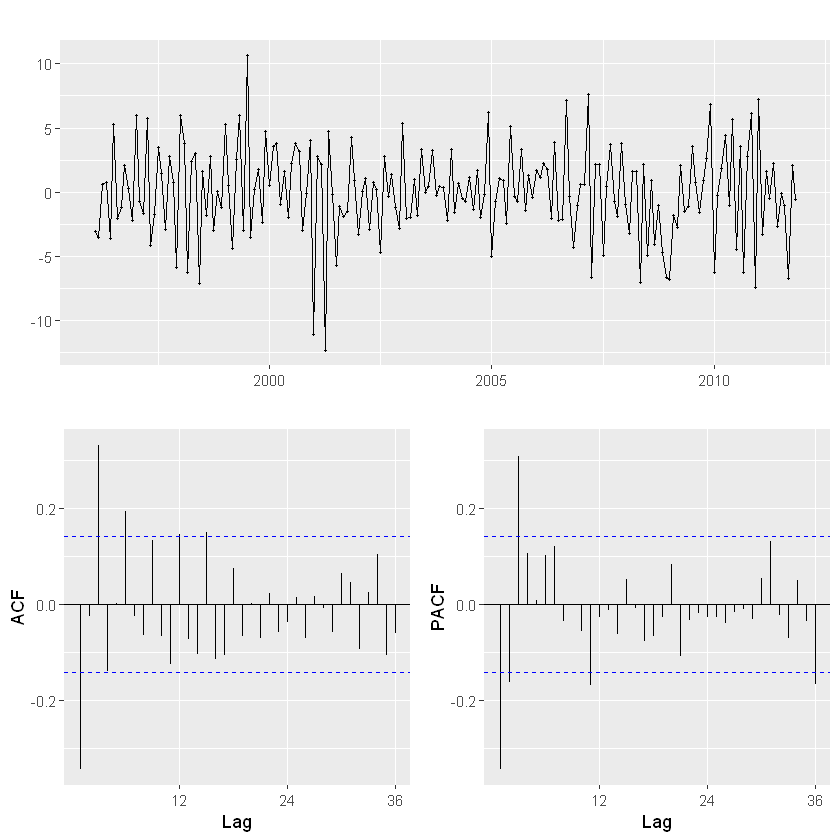

```r
eeadj %>% diff %>% ggtsdisplay(main="")
```

4. 그림에 나타낸 PACF는 AR(3) 모델을 암시합니다. 따라서, 초기 후보 모델은 ARIMA(3,1,0)입니다. 다른 분명한 후보 모델은 없습니다.
5. ARIMA(3,1,0) 모델을 ARIMA(4,1,0), ARIMA(2,1,0), ARIMA(3,1,1) 등과 함께 맞춥니다. 이 중에서 ARIMA(3,1,1)이 살짝 작은 AICc 값을 갖습니다.

```r
(fit <- Arima(eeadj, order=c(3,1,1)))
```

```
Series: eeadj
ARIMA(3,1,1)

Coefficients:
         ar1     ar2     ar3      ma1
      0.0519  0.1191  0.3730  -0.4542
s.e.  0.1840  0.0888  0.0679   0.1993

sigma^2 = 9.737:  log likelihood = -484.08
AIC=978.17   AICc=978.49   BIC=994.4
```

6. ARIMA(3,1,1) 모델에서 얻은 잔차(residual)의 ACF 그래프는 모든 자기상관 관계값이 한도 안에 들어오는 것을 나타냅니다. 이것은 잔차가 백색잡음처럼 행동하는 것을 의미합니다. 포트맨토(portmanteau) 검정이 큰 p-값을 돌려주었습니다. 이것도 잔차가 백색잡음(white noise)이라는 것을 암시합니다.

```
	Ljung-Box test

data:  Residuals from ARIMA(3,1,1)
Q* = 20.496, df = 20, p-value = 0.4273

Model df: 4.   Total lags used: 24
```

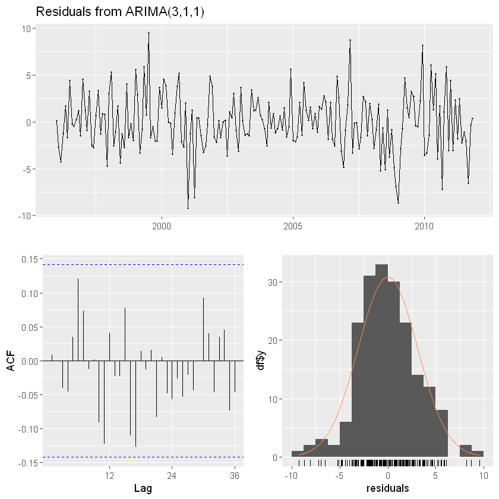

```r
checkresiduals(fit)
```

7. 그림은 고른 모델에서 얻은 예측값을 나타냅니다.

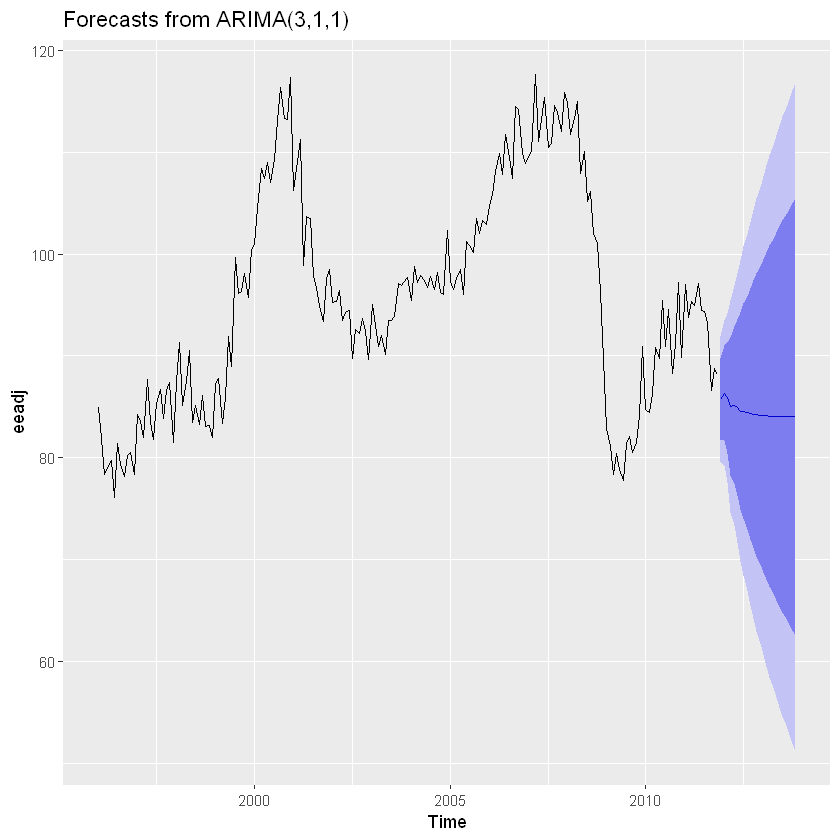

```r
autoplot(forecast(fit))
```

기본 설정을 사용한 자동화된 알고리즘을 사용했다면, ARIMA(3,1,0) 모델을 얻을 것이지만, `approximation=FALSE`을 사용했다면, ARIMA(3,1,1) 모델을 얻을 것입니다.

### R에서 상수를 이해하기

비-계절성 ARIMA 모델을 다음과 같이 쓸 수 있습니다.

$$\begin{equation} \ (1-\phi_1B - \cdots - \phi_p B^p)(1-B)^d y_t = c + (1 + \theta_1 B + \cdots + \theta_q B^q)\varepsilon_t, \end{equation}$$

또는 다음의 것과 동일하게

$$\begin{equation} \ (1-\phi_1B - \cdots - \phi_p B^p)(1-B)^d (y_t - \mu t^d/d!) = (1 + \theta_1 B + \cdots + \theta_q B^q)\varepsilon_t, \end{equation}$$

여기에서 $c = \mu(1-\phi_1 - \cdots - \phi_p )$ 이고 $μ$는 $(1-B)^d y_t$의 평균입니다. R에서는 매개변수화된 식을 사용합니다.

따라서, 정상성을 나타내지 않는 ARIMA 모델에서 상수가 포함되는 것은 예측 함수에서 차수 $d$의 다항식 추세를 유도하는 것과 같습니다. (상수가 생략되면, 예측 함수는 차수 $d-1$의 다항식 추세를 포함합니다.) $d=0$일 때는, $\mu$가 $y_t$의 평균인 특수한 상황이 됩니다.

입력값 include.mean은 $ d = 0$ 일 때만 영향을 주고 기본값은 TRUE입니다. `include.mean=FALSE`로 두면 강제로 $μ = c = 0$로 둘 것입니다.

`include.constant`라는 입력값도 있는데 TRUE이면 $d = 0$일 때 include.mean=TRUE로 둘 것이고, $d = 1$ 일 때는 `include.drift=TRUE`로 둡니다. `include.constant=FALSE`이면, `include.mean`와 `include.drift` 둘 다 FALSE로 두게 됩니다. `include.constant`을 사용하면, `include.mean=TRUE`와 `include.drift=TRUE`는 무시됩니다.

### 특성근을 그래프로 나타내기

$$\begin{equation} \ (1-\phi_1B - \cdots - \phi_p B^p)(1-B)^d y_t = c + (1 + \theta_1 B + \cdots + \theta_q B^q)\varepsilon_t, \end{equation}$$

을 다음과 같이 다시 쓸 수 있습니다.

$$\phi(B) (1-B)^d y_t = c + \theta(B) \varepsilon_t$$

여기에서 $\phi(B)= (1-\phi_1B - \cdots - \phi_p B^p)$은 $B$에 대한 $ p$ 차 다항식이고, $\theta(B) = (1 + \theta_1 B + \cdots + \theta_q B^q)$은 $B$에 $q$차 다항식입니다.

모델에 대한 정상성(stationarity) 조건은 단위 원(unit circle) 바깥에 있는 $\phi(B)$의 $ p$ 개 복소근(complex root)들이고, 역변환 가능성 조건은 단위 원 바깥에 있는 $\theta(B)$의 $q$개 복소근입니다. 따라서 복소 단위 원(complex unit circle)과 여러 근의 관계를 나타내서 모델이 역변환 가능성과 정상성을 나타내는지 확인할 수 있습니다.

대신 역 근(inverse root)은 모두 단위 원 안에 위치해야하기 때문에 그림으로 나타내는 것이 좀 더 쉽습니다. 이 작업을 R로 쉽게 할 수 있습니다. 계절성으로 조정된 전자 제품 지수를 맞추는 ARIMA(3,1,1) 모델에 대해, 그림을 얻게 됩니다.

- ARIMA(3,1,1) 모델을 계절성 조정된 전자 장비 지수에 맞춘 것에 대한 역 특성근.

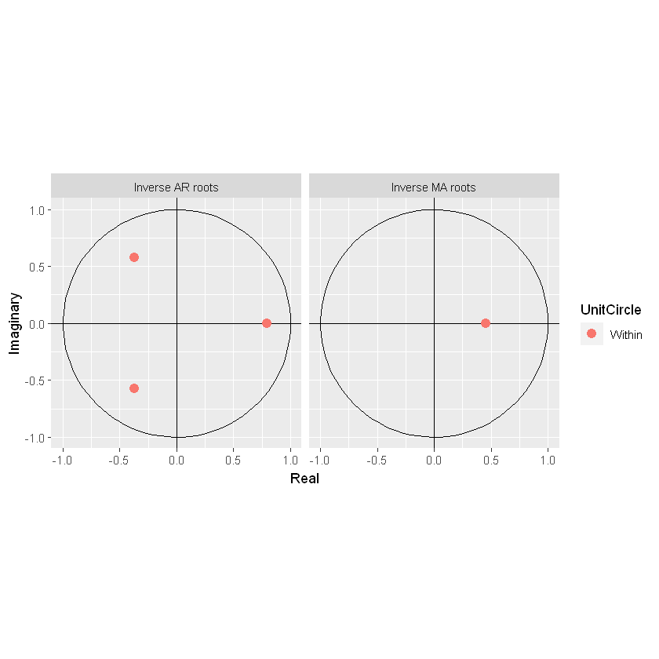

```r
autoplot(fit)
```

왼쪽 그래프에서 3개의 빨간 점은 다항식 $\phi(B)$의 근과 관계 있고, 오른쪽 그래프에서 빨간 점은 $\theta(B)$의 근과 관계 있습니다. R에서는 적합 모델(fitted model)이 반드시 정상성을 나타내면서 역변환 가능하도록 만들기 때문에 예상한 것처럼 빨간 점 모두 단위 원 안에 있습니다. 단위 원에 가까운 근은 수치적으로 불안정한 것일 수 있고, 관련 모델은 예측하기에 적합하지 않을 것입니다.

`Arima()`함수는 단위 원 바깥의 역 근(inverse root)에 해당하는 모델을 절대 결과로 내지 않을 것입니다. `auto.arima()`은 좀 더 엄격해서, 단위 원에 가까운 근에 해당하는 모델까지도 고르지 않을 것입니다.

## 08.08. 예측하기

### 점 예측치

예제에서 ARIMA 모델로부터 예측값을 계산하긴 했지만, 값을 어떻게 얻었는지는 아직 설명하지 않았습니다. 점 예측값은 다음과 같은 3가지 단계를 이용하여 계산할 수 있습니다.

1. **$y_t$가 좌변에 오고 다른 모든 항들이 우변에 오도록 ARIMA 식을 전개합니다.**
2. **$t$를 $T+h$로 바꾸어 식을 다시 씁니다.**
3. **식의 우변에서, 미래 관측값을 예측값으로 바꾸고, 미래 오차값을 0으로 바꾸고, 과거 오차값을 해당 잔차로 바꿉니다.**

$h=1$로 시작하여, 모든 예측값을 계산할 때까지 $h=2,3,\dots$에 대해 이러한 단계를 반복합니다.

이러한 과정은 예제로 가장 쉽게 이해할 수 있습니다. 이전 절에서 맞춘 ARIMA(3,1,1) 모델을 이용하여 이것을 설명할 것입니다. 모델은 다음과 같이 쓸 수 있습니다.

#### 1.

$$(1-\hat{\phi}_1B -\hat{\phi}_2B^2-\hat{\phi}_3B^3)(1-B) y_t = (1+\hat{\theta}_1B)\varepsilon_{t},$$

$$\left[1-(1+\hat{\phi}_1)B +(\hat{\phi}_1-\hat{\phi}_2)B^2 + (\hat{\phi}_2-\hat{\phi}_3)B^3 +\hat{\phi}_3B^4\right] y_t = (1+\hat{\theta}_1B)\varepsilon_{t},$$

그리고 후방이동(backshift) 연산자를 적용하면 다음과 같은 결과를 얻습니다.

$$y_t - (1+\hat{\phi}_1)y_{t-1} +(\hat{\phi}_1-\hat{\phi}_2)y_{t-2} + (\hat{\phi}_2-\hat{\phi}_3)y_{t-3} +\hat{\phi}_3y_{t-4} = \varepsilon_t+\hat{\theta}_1\varepsilon_{t-1}.$$

마지막으로, $y_t$ 이외의 다른 항을 우변으로 옮깁니다:

$$\begin{equation} \ y_t = (1+\hat{\phi}_1)y_{t-1} -(\hat{\phi}_1-\hat{\phi}_2)y_{t-2} - (\hat{\phi}_2-\hat{\phi}_3)y_{t-3} -\hat{\phi}_3y_{t-4} + \varepsilon_t+\hat{\theta}_1\varepsilon_{t-1}. \end{equation}$$

이렇게 첫 단계를 마쳤습니다. 이제 식이 ARIMA(4,0,1)처럼 보이지만, 여전히 시작했던 ARIMA(3,1,1)와 같습니다. 계수들이 정상성 조건을 만족하지 않기 때문에 ARIMA(4,0,1)로 생각할 수 없습니다.

#### 2.

두 번째 단계에서는, 식 $\begin{equation} \ y_t = (1+\hat{\phi}_1)y_{t-1} -(\hat{\phi}_1-\hat{\phi}_2)y_{t-2} - (\hat{\phi}_2-\hat{\phi}_3)y_{t-3} -\hat{\phi}_3y_{t-4} + \varepsilon_t+\hat{\theta}_1\varepsilon_{t-1}. \end{equation}$에서 $t$를 $T+1$로 바꿉니다:

$$y_{T+1} = (1+\hat{\phi}_1)y_{T} -(\hat{\phi}_1-\hat{\phi}_2)y_{T-1} - (\hat{\phi}_2-\hat{\phi}_3)y_{T-2} -\hat{\phi}_3y_{T-3} + \varepsilon_{T+1}+\hat{\theta}_1\varepsilon_{T}.$$

#### 3.

**시간 $T$까지의 관측값을 가지고 있다고 가정하고, $\varepsilon_{T+1}$을 제외하고 우변의 모든 값을 알고 있습니다. 이 값을 0으로 두고, $\varepsilon_T$ 를 마지막 관측 잔차 $e_T$ 로 둡니다:**

$$\hat{y}_{T+1|T} = (1+\hat{\phi}_1)y_{T} -(\hat{\phi}_1-\hat{\phi}_2)y_{T-1} - (\hat{\phi}_2-\hat{\phi}_3)y_{T-2} -\hat{\phi}_3y_{T-3} + \hat{\theta}_1e_{T}.$$

$$\hat{y}_{T+2|T} = (1+\hat{\phi}_1)\hat{y}_{T+1|T} -(\hat{\phi}_1-\hat{\phi}_2)y_{T} - (\hat{\phi}_2-\hat{\phi}_3)y_{T-1} -\hat{\phi}_3y_{T-2}.$$

이러한 방식으로 모든 미래 시점에 대해 과정을 계속합니다. 이러한 방법으로, 어떠한 개수의 점 예측값을 얻을 수 있습니다.

### 예측 구간

ARIMA 예측 구간(prediction interval)을 계산하는 것은 더 어렵고, 자세한 내용은 이 책의 범위를 훨씬 넘어서는 것입니다. 여기에서는 몇 가지 간단한 예제만 살펴볼 것입니다.

첫 번째 예측 구간은 계산하기 쉽습니다. $\sigma^2$가 잔차의 표준 편차이면, 95% 예측 구간은 $\hat{y}_{T+1|T} \pm 1.96\hat{\sigma}$로 주어집니다. 이 결과는 매개변수와 차수에 상관없이 모든 ARIMA 모델에 대해 참입니다.

ARIMA(0,0, q ) 모델에 대한 다-단계 예측 구간은 비교적 계산하기 쉽습니다. 모델을 다음과 같이 쓸 수 있습니다.

$$y_t = \varepsilon_t + \sum_{i=1}^q \theta_i \varepsilon_{t-i}.$$

그러면, 추정한 예측 분산을 다음과 같이 쓸 수 있습니다.

$$\hat\sigma_h = \hat{\sigma}^2 \left[ 1 + \sum_{i=1}^{h-1} \hat{\theta}_i^2\right], \qquad\text{for $h=2,3,\dots$,}$$

그리고 95% 예측 구간은 다음과 같이 $\hat{y}_{T+h|T} \pm 1.96\sqrt{\hat\sigma_h}$로 주어집니다.

AR(1) 모델을 $MA( ∞ )$로 쓸 수 있다는 것을 보였습니다. 이러한 관계를 이용하여 $MA( q )$ 모델에 대한 위의 결과를 AR(1) 모델에 대한 예측 구간을 얻기 위해 사용할 수 있습니다.

$ARIMA( p , d , q )$ 모델에 대한 다-단계 예측 구간의 다른 특수한 경우들과 더 일반적인 결과는 Brockwell & Davis (2016) 와 같이 더 수준이 높은 교과서에 있습니다.

ARIMA 모델에 대한 예측 구간은 잔차에 상관관계가 없고 잔차가 정규분포를 따른다는 가정에 기초합니다. 이러한 가정 중에서 하나라도 만족하지 않으면, 예측구간이 정확하지 않을 수 있습니다. 이러한 이유로, 예측 구간을 내기 전에 가정을 확인하기 위해 항상 ACF와 잔차의 히스토그램을 그리길 바랍니다.

일반적으로, 예측 수평선이 증가할 수록 ARIMA 모델로 얻은 예측구간은 증가합니다. 정상성을 나타내는 모델(즉, $ d = 0$ 인)의 경우에는 긴 수평선에 대해 예측구간이 실제적으로 모두 같도록 예측구간이 수렴할 것입니다. $ d ≥ 1$ 인 경우에는, 예측 구간이 시간이 지날 수록 계속 증가할 것입니다.

대부분의 예측 구간 계산에서처럼, ARIMA 기반의 구간은 너무 좁게 나타나는 경향이 있습니다. 오차값에서 분산만 고려했기 때문에 그렇습니다. 계산에 포함되지 않은 매개변수값과 모델 차수의 변동도 있습니다. 또한, 계산할 때 모델링한 과거 패턴이 예측 기간에서 계속될 것이라고 가정합니다.

## 08.09. 계절성 ARIMA 모델들

지금까지, 비-계절성 데이터와 비-계절성 ARIMA 모델에만 관심을 두었습니다. 하지만, ARIMA 모델로 다양한 종류의 계절성 데이터를 모델링 할 수도 있습니다.

계절성 ARIMA 모델은 지금까지 살펴본 ARIMA 모델에 추가적인 계절성 항을 포함하여 구성됩니다. 계절성 ARIMA 모델을 다음과 같이 쓸 수 있습니다:

| ARIMA | $\underbrace{(p, d, q)}$ | $\underbrace{(P, D, Q)_{m}}$ |
| --- | --- | --- |
|  | ${\uparrow}$ | ${\uparrow}$ |
|  | 모델의 | 모델의 |
|  | 비 계절성 부분 | 계절성 부분 |

여기에서 $m$은 매년 관측값의 개수입니다. 모델의 계절성 부분에 대문자 기호를 사용하고, 모델의 비-계절성 부분에서는 소문자 기호를 사용하겠습니다.

모델의 계절성 부분은 모델의 비-계절성 성분과 비슷한 항으로 구성됩니다만, 계절성 주기의 후방이동(backshift)을 포함합니다. 예를 들어, (상수가 없는) ARIMA(1,1,1)(1,1,1)$_4$모델은 분기별 데이터( $ m = 4$)에 대한 경우이고 다음과 같이 쓸 수 있습니다.

$$(1 - \phi_{1}B)~(1 - \Phi_{1}B^{4}) (1 - B) (1 - B^{4})y_{t} = (1 + \theta_{1}B)~ (1 + \Theta_{1}B^{4})\varepsilon_{t}.$$

단순히 추가적인 계절성 항을 비-계절성 항에 곱합니다.

### ACF/PACF

**AR이나 MA 모델의 계절성 부분은 PACF와 ACF의 계절성 시차에서 볼 수 있을 것입니다. 예를 들면, ARIMA(0,0,0)(0,0,1)$_{12}$모델은 다음과 같은 모습을 나타낼 것입니다:**

- **ACF에 시차 12에서 나타나는 뾰족한 막대는 있지만 다른 유의미한 뾰족한 막대는 없는 모습;**
- **PACF의 계절성 시차가 지수적으로 감소하는 모습(즉, 시차 12, 24, 36, …).**

비슷하게, ARIMA(0,0,0)(1,0,0)$_{12}$ 모델은 다음과 같은 모습을 나타낼 것입니다:

- ACF의 계절성 시차가 지수적으로 감소하는 모습;
- PACF에 시차 12에서 나타나는 유의미한 뾰족한 막대가 있는 모습.

계절성 ARIMA 모델에서 적절한 계절성 차수를 고려할 때, 계절성 시차를 고려하는 것에 주의하시길 바랍니다.

모델링 과정은 모델의 비-계절성 성분과 계절성 AR과 MA 항을 골라야 하는 것을 제외하고는 비-계절성 데이터에 대한 경우와 거의 같습니다. 예제를 통해 이러한 과정을 잘 익힐 수 있습니다.

### 예제: 유럽 분기별 소매 거래

1996년부터 2011년까지 분기별 유럽 소매 거래 데이터를 이용하여 계절성 ARIMA 모델링 과정을 설명하겠습니다.

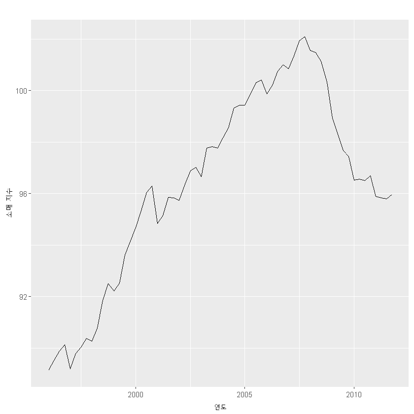

```r
autoplot(euretail) + ylab("소매 지수") + xlab("연도")
```

데이터가 정상성을 나타내지 않는다(non-stationary)는 것을 분명하게 알 수 있고 약간의 계절성도 보입니다. 따라서 먼저 계절성 차분을 구할 것입니다. 계절성으로 차분을 구한 데이터를 아래 그림에 나타냈습니다. 이것도 정상성을 나타내지 않는 것 같기 때문에, 1차 차분을 한 번 더 구하여 아래 그림에 나타냈습니다.

- 계절성 차분을 구한 유럽 소매 거래 지수..

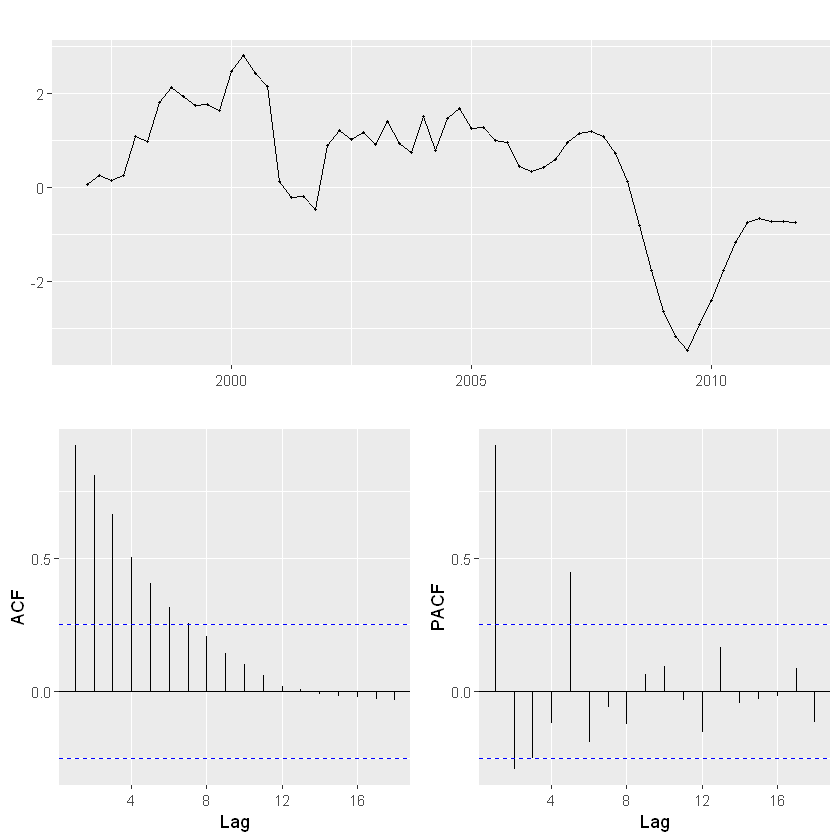

```r
euretail %>% diff(lag=4) %>% ggtsdisplay()
```

- 두 번 차분을 구한 유럽 소매 거래 지수.

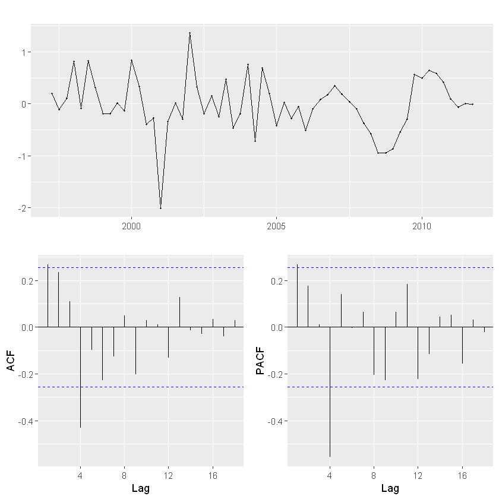

```r
euretail %>% diff(lag=4) %>% diff() %>% ggtsdisplay()
```

위의 그림에 나타낸 ACF와 PACF에 기초하여 적절한 ARIMA를 찾아봅시다. ACF에서 시차 1의 유의미하게 뾰족한 막대가 비-계절성 MA(1) 성분을 암시하고, ACF에서 시차 4의 유의미하게 뾰족한 막대는 계절성 MA(1) 성분을 암시합니다.

이를 통해, 1차 차분과 계절성 차분을 나타내는 ARIMA(0,1,1)(0,1,1)$_{4}$모델과 비-계절성과 계절성 MA(1) 성분을 가지고 시작합니다. 아래 그림에 맞춘 모델에 대한 잔차를 나타내었습니다. (비슷한 방법으로 PACF를 적용하면, ARIMA(1,1,0)(1,1,0)$_4$모델로 시작할 수 있습니다.)

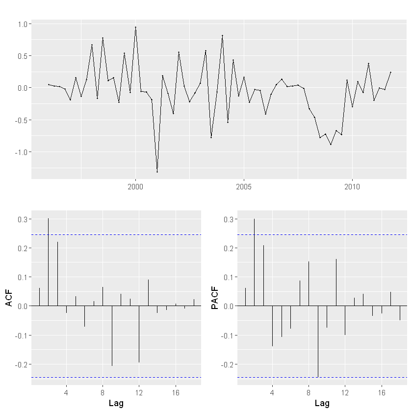

```r
euretail %>%
  Arima(order=c(0,1,1), seasonal=c(0,1,1)) %>%
  residuals() %>% ggtsdisplay()
```

ACF와 PACF 둘 다 시차 2에서 유의미하게 뾰족한 막대가 나타나고 시차 3에서 덜 유의미하지만 뾰족한 막대가 나타나는 것을 보여줍니다. 이것은 몇몇 추가적인 비-계절성 항이 모델에 추가되어야 한다는 것을 의미합니다.

ARIMA(0,1,3)(0,1,1)$_4$모델의 AICc 값은 68.53인데, ARIMA(0,1,2)(0,1,1)$_4$모델의 AICc는 74.36입니다. AR 항이 있는 다른 모델도 시도해봤지만, AICc 값이 더 작은 경우는 없었습니다.

결론적으로, ARIMA(0,1,3)(0,1,1)$_4$ 모델을 골랐습니다. 아래 그림에 잔차를 나타냈습니다. 모든 뾰족한 막대가 이제 유의미한 범위 안에 들어오고, 따라서 잔차는 백색잡음처럼 보입니다. 융-박스(Ljung-Box) 검정 결과도 잔차에 자기상관값이 남아있지 않다는 것을 보여줍니다.

```
	Ljung-Box test

data:  Residuals from ARIMA(0,1,3)(0,1,1)[4]
Q* = 0.51238, df = 4, p-value = 0.9723

Model df: 4.   Total lags used: 8
```

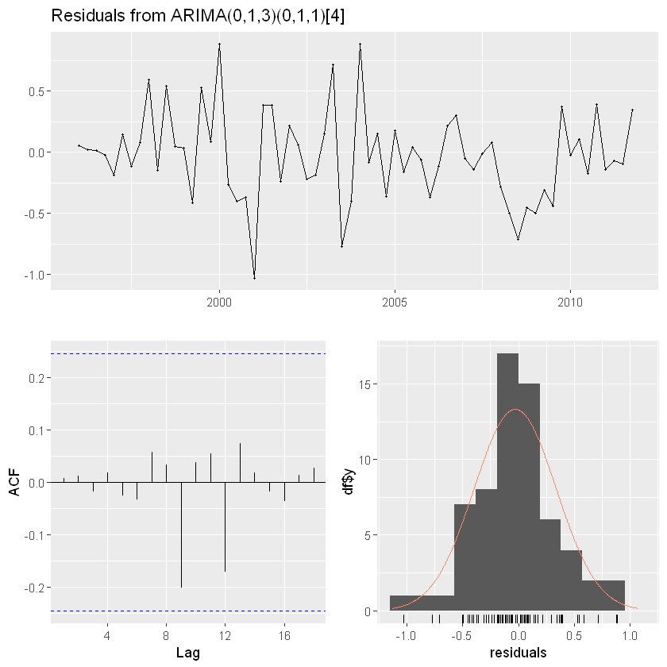

```r
fit3 <- Arima(euretail, order=c(0,1,3), seasonal=c(0,1,1))
checkresiduals(fit3)
```

따라서, 필요한 확인 절차를 거친 계절성 ARIMA 모델을 얻었고 이것으로 예측할 준비가 됐습니다. 모델로 얻은 다음 3년에 대한 예측값은 아래 그림에 나타냈습니다.

**두 번 차분을 구한 것 때문에 예측값이 데이터의 최근 추세를 따라갑니다. 크고 급격하게 증가하는 예측 구간은 소매 거래 지수가 어느때나 증가하기 또는 감소하기 시작할 수 있다는 것을 나타냅니다 — 반면에, 점 예측값은 하향세를 나타내지만, 예측구간에서 보면 데이터가 예측 기간 동안에 상향 추세를 갖는 것도 가능합니다.**

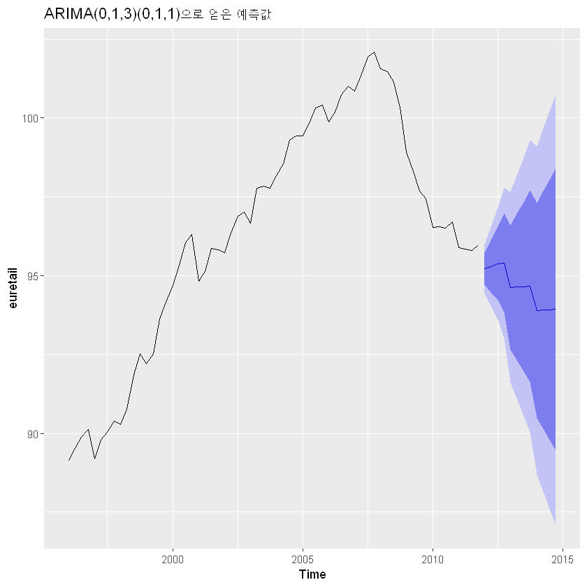

```r
fit3 %>% forecast(h=12) %>% autoplot() + ggtitle("ARIMA(0,1,3)(0,1,1)으로 얻은 예측값")
```

이 작업 대부분을 수행하기 위해 `auto.arima()`을 사용할 수도 있습니다. 이 함수를 사용하면 같은 결과를 얻습니다.

```r
auto.arima(euretail)
```

```
Series: euretail
ARIMA(0,1,3)(0,1,1)[4]

Coefficients:
         ma1     ma2     ma3     sma1
      0.2625  0.3697  0.4194  -0.6615
s.e.  0.1239  0.1260  0.1296   0.1555

sigma^2 = 0.1564:  log likelihood = -28.7
AIC=67.4   AICc=68.53   BIC=77.78
```

`auto.arima()` 함수는$ D$ (사용할 계절성 차분 횟수)를 결정하기 위해 `nsdiffs()`를 사용하고,$ d$ (보통 차분의 횟수)를 결정하기 위해 `ndiffs()`를 사용합니다. 다른 모델 매개변수는 ( $p,q,P,Q$) 비-계절성 ARIMA 모델처럼 모두 AICc를 최소화하여 결정합니다.

### 예제: 호주 코르티코 스테로이드 약물 판매량

두 번째 예제는 좀 더 어렵습니다. 호주에서 코르티코 스테로이드 (Corticosteroid) 약물이 매월 팔린 양을 예측하려고 합니다. 해부학적 치료용 화학 약품 분류 체계(Anatomical Therapeutic Chemical classification scheme)에서 H02 약물들로 분류된 것으로 알려져있습니다.

- 호주 코르티코 스테로이드 약물 판매량 (단위: 백만 처방전/월). 로그를 취한 값은 아래쪽에 나타냈습니다.

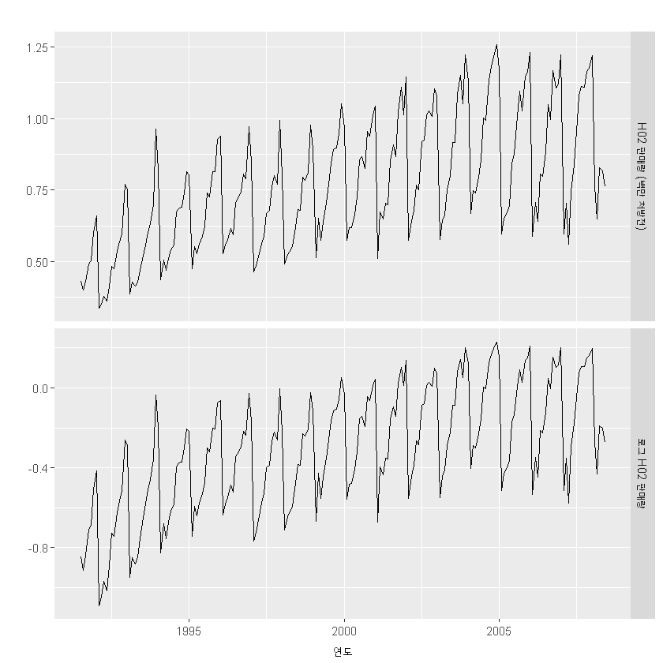

```r
lh02 <- log(h02)
cbind("H02 판매량 (백만 처방전)" = h02,
      "로그 H02 판매량"=lh02) %>%
  autoplot(facets=TRUE) + xlab("연도") + ylab("")
```

1991년 7월부터 2008년 6월까지의 데이터를 나타냈습니다. 수준의 분산이 조금 증가합니다. 따라서 분산을 안정화시키기 위해 로그를 취하겠습니다.

**데이터에는 계절성이 강하게 나타납니다. 그리고 데이터에 정상성이 나타나지 않는다는 것이 분명합니다. 그래서 계절성 차분을 사용할 것입니다.** 계절성 차분을 구한 데이터를 아래 그림에 나타냈습니다. 아직까지는 차분을 더 구해야하는지 여부를 분명하게 알기 어렵습니다. 차분을 더 계산하지 않기로 결정하지만, 확실한 선택은 아닙니다.

마지막 몇몇 관측값은 초반부의 데이터와 다른 것처럼 보입니다(더 변동이 큰 것 같은). 초반 판매량 보고가 늦어져서 데이터가 때때로 수정되는 것 때문에 생기는 현상일 수도 있습니다.

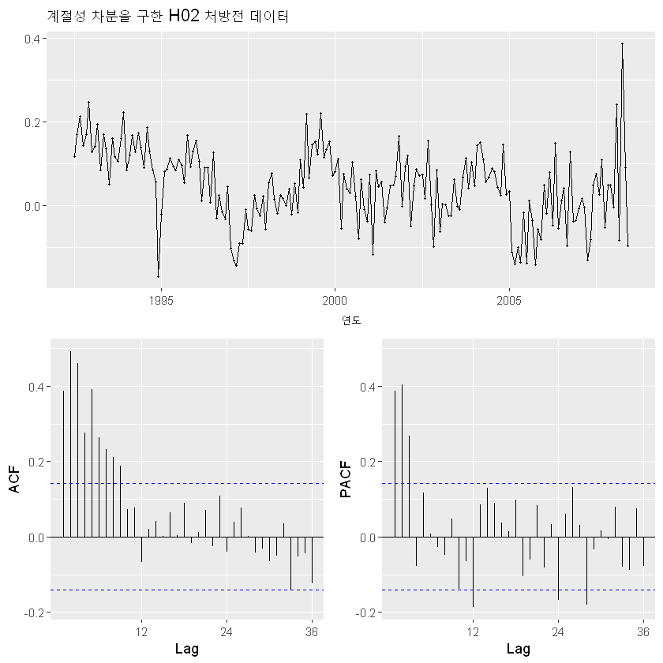

```r
lh02 %>% diff(lag=12) %>%
  ggtsdisplay(xlab="연도",
    main="계절성 차분을 구한 H02 처방전 데이터")
```

계절성 차분을 구한 데이터를 나타내는 그래프에서, PACF를 보니 시차 12와 시차 24에서 뾰족한 막대가 있습니다만, ACF를 보니 다른 계절성 시차에서는 나타나지 않습니다. 이 사실은 계절성 AR(2) 항을 암시합니다. 비-계절성 시차에서는, PACF를 보면 유의미하게 뾰족한 막대가 3개 있습니다. 이것은 AR(3) 항이 가능하다는 것을 암시합니다. ACF에서 나타나는 패턴은 어떠한 단순한 모델을 가리키지는 않습니다.

적으로, 초기 분석은 이러한 데이터에 가능한 모델이 ARIMA(3,0,0)(2,1,0)$_{12}$ 라는 것을 시사합니다. 이 모델에 몇몇 변형을 준 것과 함께 이 모델을 맞추고, AICc 값을 계산하여 다음의 표에 나타냈습니다.

| Model | AICc |
| --- | --- |
| ARIMA(3,0,1)(0,1,2)$_{12}$ | -485.5 |
| ARIMA(3,0,1)(1,1,1)$_{12}$ | -484.2 |
| ARIMA(3,0,1)(0,1,1)$_{12}$ | -483.7 |
| ARIMA(3,0,1)(2,1,0)$_{12}$ | -476.3 |
| ARIMA(3,0,0)(2,1,0)$_{12}$ | -475.1 |
| ARIMA(3,0,2)(2,1,0)$_{12}$ | -474.9 |
| ARIMA(3,0,1)(1,1,0)$_{12}$ | -463.4 |

이러한 모델 중에서 ARIMA(3,0,1)(0,1,2)$_{12}$ 모델이 가장 좋습니다(즉, 가장 작은 AICc값을 갖습니다)

```r
(fit <- Arima(h02, order=c(3,0,1), seasonal=c(0,1,2),
  lambda=0))
```

```
Series: h02
ARIMA(3,0,1)(0,1,2)[12]
Box Cox transformation: lambda= 0

Coefficients:
          ar1     ar2     ar3     ma1     sma1     sma2
      -0.1603  0.5481  0.5678  0.3827  -0.5222  -0.1768
s.e.   0.1636  0.0878  0.0942  0.1895   0.0861   0.0872

sigma^2 = 0.004278:  log likelihood = 250.04
AIC=-486.08   AICc=-485.48   BIC=-463.28
```

```
	Ljung-Box test

data:  Residuals from ARIMA(3,0,1)(0,1,2)[12]
Q* = 50.712, df = 30, p-value = 0.01045

Model df: 6.   Total lags used: 36
```

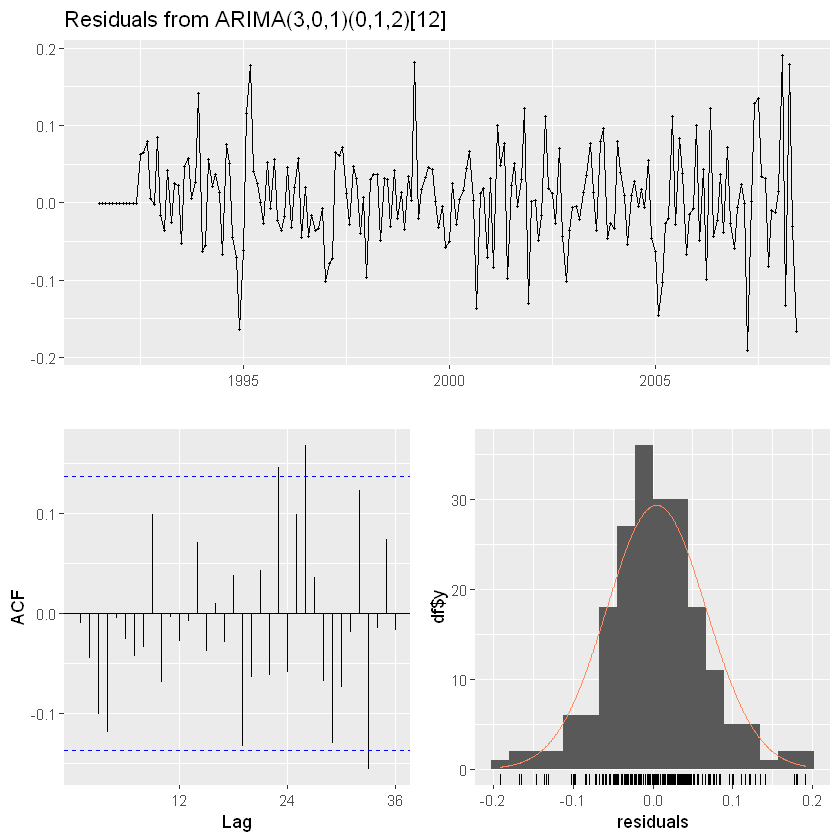

```r
checkresiduals(fit, lag=36)
```

이 모델에서 잔차는 위의 그림에 나타냈습니다. ACF를 보면 유의미하게 뾰족한 막대가 몇 개 있고, 모델은 융-박스(Ljung-Box) 검정을 통과하지 못했습니다. 여전히 모델을 예측에 사용할 수 있지만, 보정된 잔차 때문에 예측구간이 정확하지 않을 수 있습니다.

다음은 자동 ARIMA 알고리즘을 사용하여 시도해볼 것입니다. 모든 입력값을 기본 설정값으로 두고 auto.arima()를 돌리면 ARIMA(2,1,1)(0,1,2)$_{12}$ 모델을 얻습니다. 하지만, 이 모델은 여전히 시차 36에 대해 융-박스(Ljung-Box) 검정을 통과하지 못합니다. 때때로 모든 검정을 통과하는 모델을 찾지 못할 수도 있습니다.

#### 테스트 데이터 평가:

데이터의 마지막 2년으로 구성된 테스트 데이터를 이용하여 지금까지 맞춘 모델 중 몇 가지를 비교하려고 합니다. 따라서, 1991년 7월부터 2006년 6월까지의 데이터를 이용하여 모델을 맞추고, 2006년 7월부터 2008년 6월까지의 판매량을 예측하겠습니다. 결과는 표에 요약하였습니다.

다양한 ARIMA 모델을 H02 월별 처방전 판매량 데이터에 적용한 결과에 대한 RMSE 값.

| 모델 | RMSE |
| --- | --- |
| ARIMA(3,0,1)(0,1,2)$_{12}$ | 0.0622 |
| ARIMA(3,0,1)(1,1,1)$_{12}$ | 0.0630 |
| ARIMA(2,1,3)(0,1,1)$_{12}$ | 0.0634 |
| ARIMA(2,1,1)(0,1,2)$_{12}$ | 0.0634 |
| ARIMA(2,1,2)(0,1,2)$_{12}$ | 0.0635 |
| ARIMA(3,0,3)(0,1,1)$_{12}$ | 0.0637 |
| ARIMA(3,0,1)(0,1,1)$_{12}$ | 0.0644 |
| ARIMA(3,0,2)(0,1,1)$_{12}$ | 0.0644 |
| ARIMA(3,0,2)(2,1,0)$_{12}$ | 0.0645 |
| ARIMA(3,0,1)(2,1,0)$_{12}$ | 0.0646 |
| ARIMA(4,0,2)(0,1,1)$_{12}$ | 0.0648 |
| ARIMA(4,0,3)(0,1,1)$_{12}$ | 0.0648 |
| ARIMA(3,0,0)(2,1,0)$_{12}$ | 0.0661 |
| ARIMA(3,0,1)(1,1,0)$_{12}$ | 0.0679 |

RMSE 값을 기준으로 볼 때 직접 고른 모델과 auto.arima() 둘 다 상위 4개의 모델에 포함됩니다.

AICc 값으로 모델을 비교할 때, 모든 모델을 같은 차수로 차분을 구한 것이 중요합니다. 하지만, 테스트 데이터을 사용하여 모델을 비교할 때, 예측값이 어떻게 나왔는지가 중요하지 않습니다 — 이러한 비교가 항상 유효합니다. 결과적으로, 위의 표에서, 계절성 차분만 고려한 몇몇 모델과 1차 차분과 계절성 차분 둘 다 고려한 몇몇 모델을 포함시킬 수 있습니다. 반면에, AICc 값을 포함하는 이전의 표에서는 1차 차분은 비교 대상에 포함하지 않고 계절성 차분을 고려한 모델만 비교했습니다.

살펴본 모델 중에서 어떠한 것도 잔차 검정을 전부 통과하지 못했습니다. 실제 상황에서, 보통은 모델이 모든 검정을 통과하지 못하더라도 찾을 수 있었던 가장 좋은 모델을 사용합니다.

(테스트 데이터에 대해 가장 낮은 RMSE 값과 계절성 차분을 고려한 모델 중에서 가장 좋은 AICc 값을 갖는) ARIMA(3,0,1)(0,1,2)$_{12}$ 모델로 얻은 예측값을 그림에 나타냈습니다.

- ARIMA(3,0,1)(0,1,2)$_{12}$ 모델을 H02 월별 처방전 판매량 데이터에 적용한 결과로부터 얻은 예측값.

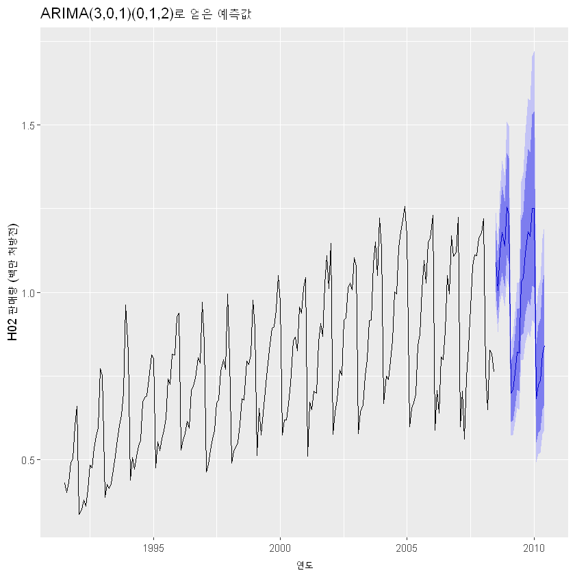

```r
h02 %>%
  Arima(order=c(3,0,1), seasonal=c(0,1,2), lambda=0) %>%
  forecast() %>%
  autoplot() +
    ylab("H02 판매량 (백만 처방전)") + xlab("연도") +
    ggtitle("ARIMA(3,0,1)(0,1,2)로 얻은 예측값")
```

## 08.10. ARIMA vs ETS

ARIMA 모델이 지수평활(exponential smoothing)보다 더 일반적이라는 근거없는 믿음을 갖기 쉽습니다. 선형 지수 평활 모델이 ARIMA 모델의 특수한 경우이지만, 비-선형 지수 평활 모델은 ARIMA에 대응되는 부분이 없습니다. 반면에, 많은 ARIMA 모델은 지수평활에 대응되지 않습니다. 특히, 모든 ETS 모델은 정상성을 나타내지 않는 경우에 맞지만, 몇몇 ARIMA 모델은 정상성을 나타내는 경우에 맞습니다.

계절성이나 비-감쇠 추세 아니면 둘 다 있는 ETS 모델은 2개의 단위근(unit root)을 갖습니다(즉, 정상성을 나타내도록 만들려면 차분을 2번 구해야한다는 것입니다). 다른 모든 ETS 모델은 1개의 단위근을 갖습니다(즉, 정상성을 나타내도록 만들려면 차분을 1번 구해야한다는 것입니다).

표는 두 종류의 모델에 대해 대응 관계를 나타낸 것입니다. 계절성 모델은 ARIMA 매개변수에 많은 수의 제약조건이 있습니다.

Table 8.3: ETS와 ARIMA 모델 사이의 동치 관계.

| ETS 모델 | ARIMA 모델 | 매개변수 |
| --- | --- | --- |
| ETS(A,N,N) | ARIMA(0,1,1) | $\theta_1=\alpha-1$ |
| ETS(A,A,N) | ARIMA(0,2,2) | $\theta_1=\alpha+\beta-2$ |
|  |  | $\theta_2=1-\alpha$ |
| ETS(A,A$_d$,N) | ARIMA(1,1,2) | $\phi_1=\phi$ |
|  |  | $\theta_1=\alpha+\phi\beta-1-\phi$ |
|  |  | $\theta_2=(1-\alpha)\phi$ |
| ETS(A,N,A) | ARIMA(0,1,$m$)(0,1,0)$_m$ |  |
| ETS(A,A,A) | ARIMA(0,1,$m+1$)(0,1,0)$_m$ |  |
| ETS(A,A$_d$,A) | ARIMA(0,1,$m+1$)(0,1,0)$_m$ |  |

AICc는 같은 범주(class)에 속하는 모델을 고르는데 유용합니다. 예를 들면, AICc를 후보가 될만한 ARIMA 모델 중에서 어떤 ARIMA 모델을 고르거나 후보가 될만한 ETS 모델 중에서 어떤 ETS 모델을 고를 때 사용할 수 있습니다. 하지만, ETS와 ARIMA 모델은 서로 다른 모델 범주(class)에 속하기 때문에 ETS와 ARIMA 모델은 서로 비교할 때는 사용할 수 없습니다. 아래의 예제는 이러한 범주에 속하는 모델 중에서 고르는 방식을 나타냅니다.

### 예제: 비-계절성 데이터에서 `auto.arima()`와 `ets()` 비교하기

ARIMA 모델과 ETS 모델을 비교할 때 시계열 교차검증(cross validation)을 사용할 수 있습니다. 아래의 코드는 각각 auto.arima()와 ets()가 시계열 객체를 결과로 돌려주는 함수를 나타냅니다.

```r
fets <- function(x, h) {
  forecast(ets(x), h = h)
}

farima <- function(x, h) {
  forecast(auto.arima(x), h=h)
}
```

돌려받은 객체는 `tsCV()`로 넘길 수 있습니다.

- Compute CV errors for ETS as e1

```r
e1 <- tsCV(ausair, fets, h=1)
```

- Compute CV errors for ARIMA as e2

```r
e2 <- tsCV(ausair, farima, h=1)
```

- Find MSE of each model class

```r
mean(e1^2, na.rm=TRUE)
```

2.84481885850474

```r
mean(e2^2, na.rm=TRUE)
```

2.88531996756446

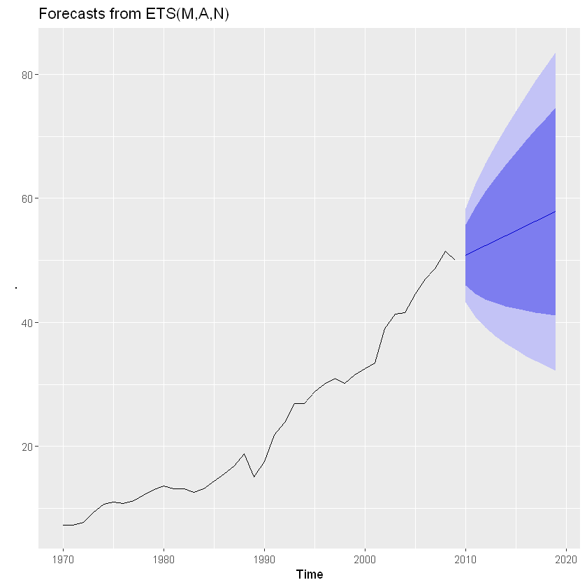

```r
ausair %>% ets() %>% forecast() %>% autoplot()
```

### 예제: 계절성 데이터에서 auto.arima()와 ets() 비교하기

여기에서는 분기별 시멘트 생산 데이터 qcement에 적용한 계절성 ARIMA와 ETS 모델을 비교해보려고 합니다. 시계열이 아주 길기 때문에, 시계열 교차 검증보다는 데이터를 학습 데이터와 테스트 데이터로 나누어 사용해도 되겠습니다. 이렇게 데이터를 나누면 계산 속도가 아주 빠르다는 장점이 있습니다. 1988년 초부터 2007년 말까지를 학습 데이터로 두고 `auto.arima()`와 `ets()` 함수를 이용하여 ARIMA와 ETS 모델을 고르겠습니다.

```r
cement <- window(qcement, start=1988)
```

```r
train <- window(cement, end=c(2007,4))
```

아래의 결과는 `auto.arima()`로 고르고 추정한 ARIMA 모델을 나타냅니다. 잔차가 백색잡음인 것처럼 나타나기 때문에, ARIMA 모델은 데이터의 모든 동역학을 잘 잡아냅니다.

```r
(fit.arima <- auto.arima(train))
```

```
Series: train
ARIMA(1,0,1)(2,1,1)[4] with drift

Coefficients:
         ar1      ma1   sar1     sar2     sma1   drift
      0.8886  -0.2366  0.081  -0.2345  -0.8979  0.0105
s.e.  0.0842   0.1334  0.157   0.1392   0.1780  0.0029

sigma^2 = 0.01146:  log likelihood = 61.47
AIC=-108.95   AICc=-107.3   BIC=-92.63
```

```
	Ljung-Box test

data:  Residuals from ARIMA(1,0,1)(2,1,1)[4] with drift
Q* = 0.78311, df = 3, p-value = 0.8535

Model df: 5.   Total lags used: 8
```

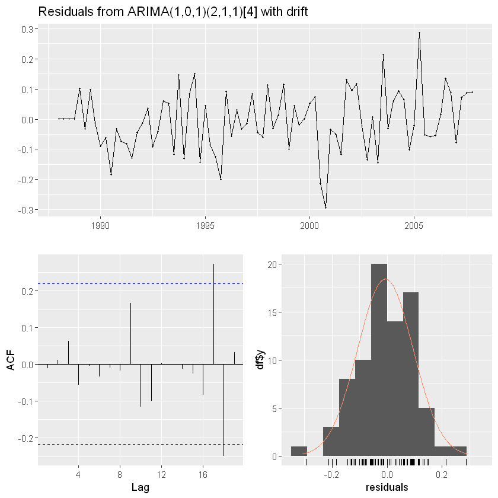

```r
checkresiduals(fit.arima)
```

아래의 결과는 `ets()`로 고르고 추정한 ETS 모델을 나타냅니다. 여기에서도 잔차가 백색잡음인 것처럼 나타나기 때문에, 이 모델도 데이터의 모든 동역학을 잘 잡아냅니다.

```r
(fit.ets <- ets(train))
```

```
ETS(M,N,M)

Call:
 ets(y = train)

  Smoothing parameters:
    alpha = 0.7341
    gamma = 1e-04

  Initial states:
    l = 1.6439
    s = 1.031 1.0439 1.0103 0.9148

  sigma:  0.0581

       AIC       AICc        BIC
-2.1967020 -0.6411464 14.4774845
```

```
	Ljung-Box test

data:  Residuals from ETS(M,N,M)
Q* = 6.3457, df = 3, p-value = 0.09595

Model df: 6.   Total lags used: 9
```

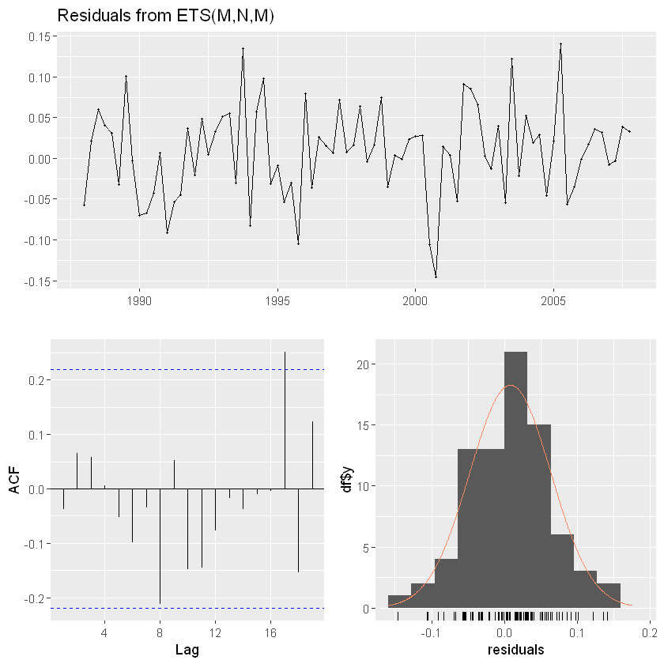

```r
checkresiduals(fit.ets)
```

아래의 결과에서 두 후보 모델의 예측 성능을 검증 데이터에 대해 평가합니다. 이 경우에 테스트 데이터에 대한 RMSE, MAPE, MASE에 기초해서 보면, ETS 모델이 살짝 더 정확한 모델인 것처럼 보입니다.

```r
a1 <- fit.arima %>% forecast(h = 4*(2013-2007)+1) %>%
  accuracy(qcement)

a1[,c("RMSE","MAE","MAPE","MASE")]
```

A matrix: 2 × 4 of type dbl

|  | RMSE | MAE | MAPE | MASE |
| --- | --- | --- | --- | --- |
| Training set | 0.1001195 | 0.07988903 | 4.372443 | 0.5458078 |
| Test set | 0.1996098 | 0.16882205 | 7.719241 | 1.1534049 |

```r
a2 <- fit.ets %>% forecast(h = 4*(2013-2007)+1) %>%
  accuracy(qcement)

a2[,c("RMSE","MAE","MAPE","MASE")]
```

A matrix: 2 × 4 of type dbl

|  | RMSE | MAE | MAPE | MASE |
| --- | --- | --- | --- | --- |
| Training set | 0.1022079 | 0.07958478 | 4.371823 | 0.5437292 |
| Test set | 0.1838791 | 0.15395141 | 6.986077 | 1.0518075 |

ARIMA 모델이 ETS 모델보다 학습 데이터를 살짝 더 잘 맞추지만 ETS 모델이 테스트 데이터에 대한 더 정확한 예측값을 내는 것에 주목합시다. 학습 데이터를 잘 맞춘다고 해서 모델이 예측을 잘 할 것이라는 것을 의미하지 않습니다.

아래에서 ETS 모델로부터 다음 3년에 해당하는 예측값을 내고 값을 그래프로 나타냅니다.

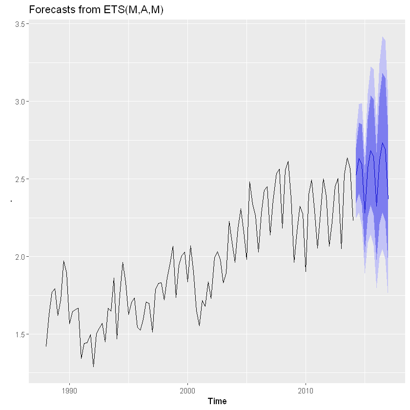

```r
cement %>% ets() %>% forecast(h=12) %>% autoplot()
```